# Классические_статистические_тесты.ДЗ

Ekaterina Vostokova

2024-11-25

# Инструкции

Ниже приведены семь клинических (исследовательских) гипотез. В качестве задания протестируйте их, используя соответствующие статистические критерии. Решение должно содержать все элементы алгоритма проверки статистических гипотез:

• Сформулируете нулевую и альтернативную гипотезы. • Укажите уровень значимости α. • Определите статистический тест (критерий) для проверки гипотезы. При необходимости аргументируйте выбор одностороннего теста. • Укажите критическое значение статистики (используйте распределения из материалов лекции). • Определите наблюдаемое значение статистики. • Оцените статистическую значимость (p-value и/или доверительный интервал). • Оцените практическую значимость.

- Решение необходимо загружать в формате Rmd (воспроизводимый код). ** Данные для анализа необходимо генерировать самостоятельно в соответствии с каждой представленной гипотезой. По возможности используйте пакет dplyr *** Предусмотрен мягкий дедлайн (17 ноября). В этом случае вы получите комментарии с возможностью повысить оценку. Сдача работы после жёсткого дедлайна (24 ноября) предусматривает снижение оценки (10 баллов).

# Гипотеза 1. Существует ассоциация между уровнем физической активности (бинарная переменная, физическая активность может быть ‘высокой’ и ‘низкой’) и частотой возникновения сердечно-сосудистых заболеваний у пациентов старше 50 лет. Попробуйте вариант с большими выборками (sample_size <- 100). Как изменится стратегия при малых выборках (sample_size <- 30) ?

## Генерация данных

Нулевая гипотеза: Между уровнем физической активности (бинарная переменная, физическая активность может быть ‘высокой’ и ‘низкой’) и частотой возникновения сердечно-сосудистых заболеваний у пациентов старше 50 лет нет связи.

Альтернативная гипотеза: Между уровнем физической активности (бинарная переменная, физическая активность может быть ‘высокой’ и ‘низкой’) и частотой возникновения сердечно-сосудистых заболеваний у пациентов старше 50 лет есть связь.

Уровень статистической значимости α = 0.05.

Для проверки гипотезы будет использоваться хи-квадрат в случае выборки в 100 пациентов, точный тест Фишера в случае выборки в 30 пациентов.

```r
# Воспроизводимость результатов
set.seed(42)

# Общий размер выборки
sample_size_100 <- 100

# Генерация данных по физической активности (бинарная переменная) в фиксированном соотношении 1:1
activity_100 <- sample(c("high", "low"), size = sample_size_100, replace = TRUE, prob = c(0.5, 0.5))

# Генерация данных по наличию сердечно-сосудистых заболеваний (бинарная переменная)
# У активных людей меньше вероятность заболеть (0.5 vs 0.6)

cardio_100 <- ifelse(activity_100 == "high",
                 rbinom(sample_size_100, 1, 0.5),
                 rbinom(sample_size_100, 1, 0.6))
```

```r
# Воспроизводимость результатов
set.seed(42)

# Общий размер выборки
sample_size_30 <- 30

# Генерация данных по физической активности (бинарная переменная) в фиксированном соотношении 1:1
activity_30 <- sample(c("high", "low"), size = sample_size_30, replace = TRUE, prob = c(0.5, 0.5))

# Генерация данных по наличию сердечно-сосудистых заболеваний (бинарная переменная)
# У активных людей меньше вероятность заболеть (0.5 vs 0.6)

cardio_30 <-  ifelse(activity_30 == "high",
                 rbinom(sample_size_30, 1, 0.5),
                 rbinom(sample_size_30, 1, 0.6))
```

## Решение

Для выборки в 100 пациентов.

```r
chisq_test_100 <- chisq.test(table(activity_100, cardio_100))
chisq_test_100
```

```
##
##  Pearson's Chi-squared test with Yates' continuity correction
##
## data:  table(activity_100, cardio_100)
## X-squared = 3.0784, df = 1, p-value = 0.07934
```

Получаем p-value 0.08, соответственно не можем отвергнуть нулевую гипотезу.

Для выборки в 30 пациентов (альтернативно можем использовать точный тест Фишера).

```r
fisher_30 <- fisher.test(table(activity_30, cardio_30))
fisher_30
```

```
##
##  Fisher's Exact Test for Count Data
##
## data:  table(activity_30, cardio_30)
## p-value = 0.702
## alternative hypothesis: true odds ratio is not equal to 1
## 95 percent confidence interval:
##   0.2465195 11.9826442
## sample estimates:
## odds ratio
##   1.533185
```

В данном случае также не можем отвергнуть нулевую гипотезу.

# Гипотеза 2. Применение нового метода лечения для пациентов с артериальной гипертензией приведет к уменьшению среднего артериального давления по сравнению с пациентами, получающими стандартное лечение.

Нулевая гипотеза: нет разницы в уровне среднего артериального давления у пациентов с артериальной гипертензией, получающих стандартное лечение и новую терапию.

Альтернативная гипотеза: Уровни среднего артериального давления у пациентов с артериальной гипертензией, получающих стандартное лечение и новую терапию, различаются.

Уровень статистической значимости α = 0.05.

Используем t-test.

## Генерация данных

```r
# Воспроизводимость результатов
set.seed(42)

# Размер выборки (в каждой группе)
sample_size <- 80


# В популяции c экспериментальным методом лечения средний уровень систолического артериального давления меньше (130 vs 135 mm)
# Генерация данных для группы с новым методом лечения
group1 <- rnorm(sample_size, mean = 130, sd = 10)  # экспериментальная группа

# Генерация данных для группы со стандартным лечением
group2 <- rnorm(sample_size, mean = 135, sd = 10)  # контрольная группа
```

## Решение

```r
t_test_out <- t.test(group1, group2)
t_test_out
```

```
##
##  Welch Two Sample t-test
##
## data:  group1 and group2
## t = -2.3719, df = 154.28, p-value = 0.01893
## alternative hypothesis: true difference in means is not equal to 0
## 95 percent confidence interval:
##  -6.8745373 -0.6268427
## sample estimates:
## mean of x mean of y
##  130.2015  133.9522
```

P-value < 0.05, соответственно есть основания отвергнуть нулевую гипотезу и считать, что разница между стандартным и новым методами лечения действительно значима.

# Гипотеза 3. Внедрение программы реабилитации для пациентов с хронической болью в спине приведет к улучшению их физической активности (предположим что физическую активность можно оценить по шкале 0-100)

Нулевая гипотеза: физическая активность пациентов с хронической болью в спине не отличается при внедрении программы реабилитации и при ее отсутствии.

Альтернативная гипотеза: физическая активность пациентов с хронической болью в спине улучшается при внедрении программы реабилитации.

Уровень статистической значимости α = 0.05.

Используем парный t-test, так как сравниваем одних и тех же пациентов до и после реабилитации. ## Генерация данных

```r
# Воспроизводимость результатов
set.seed(42)

# Размер выборки
sample_size <- 30

# В популяции до реабилитации средний уровень физической активности меньше (50 vs 60)
# Генерация данных до реабилитации
before <- rnorm(sample_size, mean = 50, sd = 10)

# Генерация данных после реабилитации
after <- rnorm(sample_size, mean = 60, sd = 10)
```

## Решение

```r
paired_test <- t.test(before, after, paired = TRUE)
paired_test
```

```
##
##  Paired t-test
##
## data:  before and after
## t = -2.4726, df = 29, p-value = 0.01952
## alternative hypothesis: true mean difference is not equal to 0
## 95 percent confidence interval:
##  -14.790819  -1.399274
## sample estimates:
## mean difference
##       -8.095047
```

P-value < 0.05, есть основания отклонить нулевую гипотезу, наблюдаем значимое улучшение физической активности пациентов после внедрения программы реабилитации.

# Гипотеза 4. Применение нового метода лечения для пациентов с инфарктом миокарда увеличит долю вернувшихся к нормальной физической активности

Нулевая гипотеза: нет различия в долях пациентов, вернувшихся к нормальной физической активности после инфаркта миокарда, при применении нового метода лечения и со стандартной терапией.

Альтернативная гипотеза: применение нового метода лечения изменяет долю вернувшихся к нормальной физической активности пациентов после инфаркта миокарда.

Уровень статистической значимости α = 0.05.

Используем хи-квадрат.

## Генерация данных

```r
# Воспроизводимость результатов
set.seed(42)

# Общий размер выборки
sample_size <- 200


# В популяции экспериментального лечения вероятность нормальной физической активности больше (0.7 vs 0.65)
# Генерация данных по статусу лечение (бинарная переменная, новый метод или стандарт) в фиксированном соотношении 1:1
treatment <- sample(c("new", "old"), size = sample_size, replace = TRUE, prob = c(0.5, 0.5))


# Генерация данных по физической активности после лечения (бинарная переменная)
activity <- ifelse(treatment == "new",
                   rbinom(sample_size, 1, 0.7),
                   rbinom(sample_size, 1, 0.65))
```

## Решение

```r
chisq_test <- chisq.test(table(treatment, activity))
chisq_test
```

```
##
##  Pearson's Chi-squared test with Yates' continuity correction
##
## data:  table(treatment, activity)
## X-squared = 2.8022, df = 1, p-value = 0.09414
```

По результатам теста не можем отвергнуть нулевую гипотезу.

# Гипотеза 5. Применение медитации в течение 8 недель повлияет на наличие стресса (есть/нет) у лиц с высоким уровнем тревожности.

Нулевая гипотеза: наличие стресса не изменяется при применении медитации в течение 8 недель у лиц с высоким уровнем тревожности.

Альтернативная гипотеза: наличие стресса изменяется при применении медитации в течение 8 недель у лиц с высоким уровнем тревожности.

Уровень значимости α = 0.05

Так как у нас зависимые бинарные данные, можем использовать тест Мак-Нимара.

## Генерация данных

```r
# Воспроизводимость результатов
set.seed(42)

# Размер выборки
sample_size <- 50

# Генерация данных до медитации (бинарная переменная) в фиксированном соотношении 1:1
before <- sample(c(0, 1), size = sample_size, replace = TRUE, prob = c(0.5, 0.5))

# Генерация данных после медитации (бинарная переменная). После медитации вероятность наличия стресса меньше (0.2 vs 0.4)
after <- ifelse(before == 0,
                rbinom(sample_size, 1, 0.2),
                rbinom(sample_size, 1, 0.4))
```

## Решение

```r
mcnemar_test <- mcnemar.test(table(before, after))
mcnemar_test
```

```
##
##  McNemar's Chi-squared test with continuity correction
##
## data:  table(before, after)
## McNemar's chi-squared = 4.0833, df = 1, p-value = 0.04331
```

P-value согласно тесту 0.04, при выбранном нами уровне значимости мы имеем основания отвергнуть нулевую гипотезу и считать, что примение медитации в течение 8 недель у лиц с высоким уровнем тревожности влияет на наличие стресса.

# Гипотеза 6. Применение альтернативного метода лечения для пациентов с биполярным расстройством приведет к значимому изменению уровня симптомов депрессии по отношению к группе, прошедшей стандартное лечение (депрессию можно определить по шкале от 0 до 100, при этом исследователь должен избегать любых предположений (кроме i.i.d.)).

## Генерация данных

Нулевая гипотеза: уровень симптомов депрессии не отличается в группах со стандартным и альтернативных лечением для пациентов с биполярным расстройством.

Альтернативная гипотеза: В группах со стандартным и альтернативных лечением для пациентов с биполярным расстройством уровень симптомов депрессии будет различаться.

Уровень значимости α = 0.05

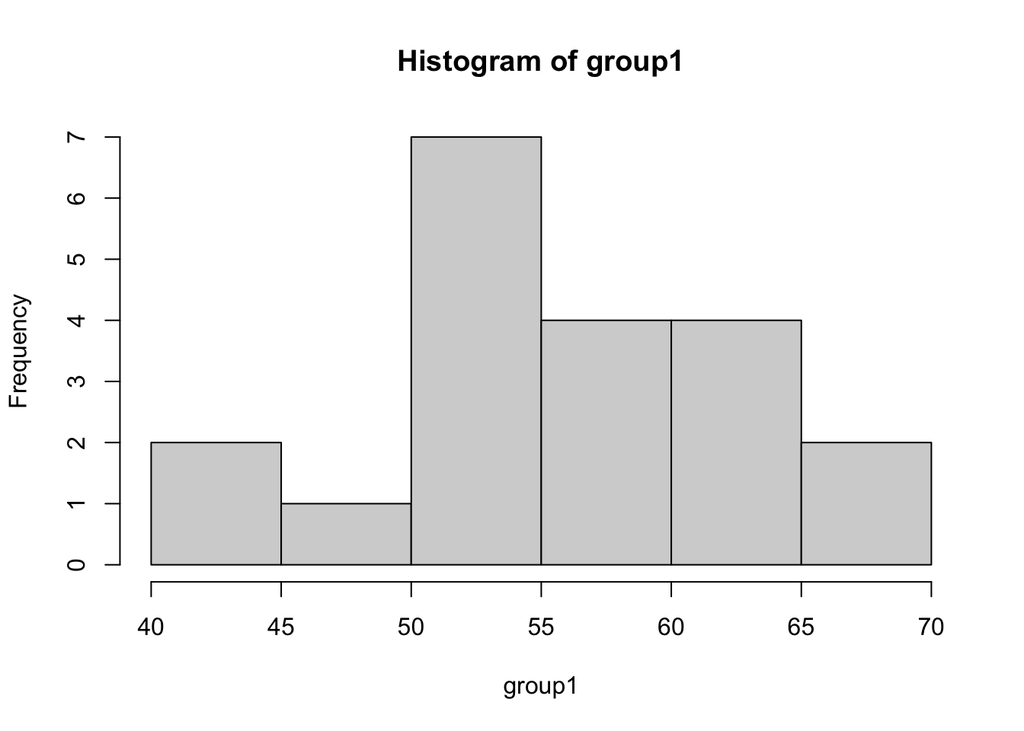

```r
# Воспроизводимость результатов
set.seed(42)

# Размер выборки для каждой группы
sample_size <- 20


# В популяции c экспериментальным методом лечения среднее депрессии меньше (55 vs 68)
# Генерация данных для экспериментальной группы
group1 <- rnorm(sample_size, mean = 55, sd = 5)  # экспериментальная группа

# Генерация данных для группы со стандартным лечением
group2 <- rnorm(sample_size, mean = 68, sd = 5)  # контрольная группа

hist(group1)
```

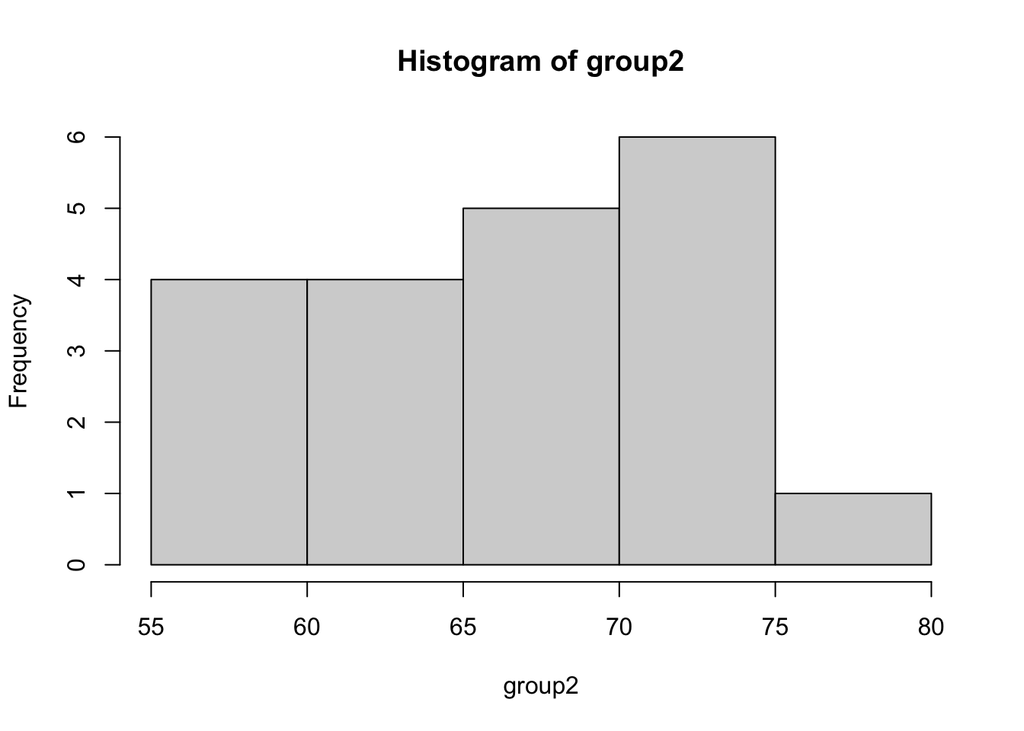

```r
hist(group2)
```

По гистограммам видим, что распределение не нормальное, поэтому используем тест Манн-Уитни. ## Решение

```r
wilcox_test <- wilcox.test(group1, group2)
wilcox_test
```

```
##
##  Wilcoxon rank sum exact test
##
## data:  group1 and group2
## W = 37, p-value = 1.654e-06
## alternative hypothesis: true location shift is not equal to 0
```

C данными условиями получаем p-value < 0.05, можем отвергнуть нулевую гипотезу и считаем, что в группах со стандартным и альтернативных лечением для пациентов с биполярным расстройством уровень симптомов депрессии будет различаться.

# Гипотеза 7. Длительность сна (в часах) ассоциирована с уровенем стресса у студентов (шкала с нормальным распределением)

## Генерация данных

```r
library(mvtnorm) # библиотека mvtnorm для работы с многомерным нормальным распределением
# Воспроизводимость результатов
set.seed(42)

# Размер выборки
sample_size <- 100

# Средние значения для длительности сна (HoursOfSleep) и уровня стресса (StressLevel) в популяции
means <- c(7, 5)

# Матрица ковариации. В ислледуемой популяции HoursOfSleep и StressLevel ассоциированы отрицательно (r = -0.5)
cov_matrix <- matrix(c(1, -0.5, -0.5, 1), nrow = 2)

df <- rmvnorm(n = sample_size,
              mean = means,
              sigma = cov_matrix) %>%
      as_tibble() %>%
      setNames(c("HoursOfSleep", "StressLevel"))
```

## Решение (дополните решение визуализацией)

```r
correlation_test <- cor.test(df$HoursOfSleep, df$StressLevel)
correlation_test
```

```
##
##  Pearson's product-moment correlation
##
## data:  df$HoursOfSleep and df$StressLevel
## t = -6.0621, df = 98, p-value = 2.511e-08
## alternative hypothesis: true correlation is not equal to 0
## 95 percent confidence interval:
##  -0.6517877 -0.3630480
## sample estimates:
##        cor
## -0.5222265
```

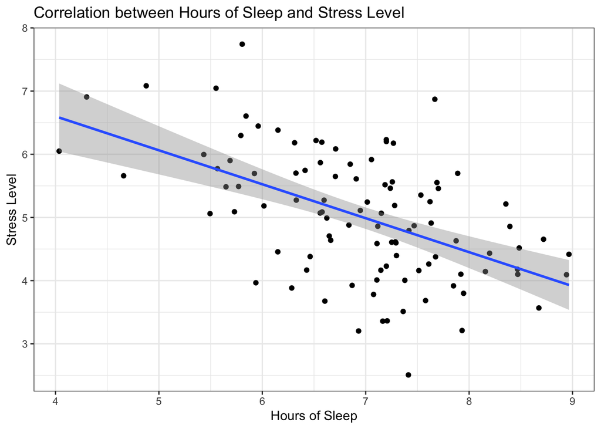

```r
ggplot(df, aes(x = HoursOfSleep, y = StressLevel)) +
  geom_point() +
  geom_smooth(method = "lm", se = TRUE) +
  theme_bw() +
  labs(title = "Correlation between Hours of Sleep and Stress Level",
       x = "Hours of Sleep",
       y = "Stress Level")
```

Уровень стресса имеет отрицательную взаимосвязь с количеством часов сна. Это подтверждается как тестом, так и визуализацией.